# Demand Shocks & Special Districts

Evidence from Chinese Import Shocks

Christopher B. Goodman

cgoodman@niu.edu

Northern Illinois University

February 14, 2025

What is the importance of manufacturers in the creation and dissolution of special districts?

## Introduction

- Special districts are a unique form of local government that provide a single service or a limited number of services
  - A defining characteristic: *lack of durability*
  - Special districts are created and dissolved frequently
- What leads to these changes?
  - Changes in demand for services
  - Changes in state laws
  - Changes in local politics

## Introduction

- Manufacturers are often viewed as *boundary change entrepreneurs*
  - Individuals (or groups of individuals) who seek to alter (or preserve) the boundaries of local governments for both collective and selective gain
  - Identifying such individuals is exceedingly difficult outside of case studies
  - Proxies or conditions conducive to the emergence of such entrepreneurs are used in the literature
- If manufacturers (and their employees) become more or less important in the local area, what happens to special districts?
  - Concern: Services provided by special districts may elevate manufacturers
  - Solution: Look for shocks, instruments, or both

## Preview of results

- Use Chinese import shocks, instrumented using Autor, Dorn, and Hanson (2013), to examine changes in the importance of manufacturers
  - The rising threat of Chinese imports worked to diminish U.S. manufacturing, reaching and inflection in 2001 when China joins the World Trade Organization (WTO)
  - Areas experienced this shock differently
- A $1,000 increase in import exposure per worker leads to between 1.9 and 3.1 district reduction among urban and urban adjacent commuting zones
  - As manufacturers become less important in the local economy, the support for special district declines

## A primer on special districts

> *Special district governments are independent, special purpose governmental units that exist as separate entities with substantial administrative and fiscal independence from general purpose local governments* – U.S. Census Bureau
- *Administrative independence*
  - A sufficiently independent governing board, elected or appointed (or both), without interference from other governments
- *Fiscal independence*
  - The ability to adopt a budget, levy taxes and/or fees, and issue debt without interference from other governments
- Typically, a district is classified as “dependent” because of violations of administrative independence

## A primer on special districts

**Important features**

- Typically single function
- *Territorial flexibility*
  - Can overlap other governments, including other special districts
  - Borders are more easily changed
  - Districts typically choose their constituents
- Usually exempt from various laws governing general purpose governments
  - Voting share may be apportioned on any number of bases, land ownership is most common

## A primer on special districts

- Popular but growth has been slowing
- Most common areas of specialization
  - Fire protection
  - Water supply
  - Housing & community development
- Net counts mask significant churn (many created and many dissolved each period)

| Year | No. of districts | Share of all govts |
| --- | --- | --- |
| 1972 | 23,885 | 30.5% |
| 1982 | 28,078 | 34.3% |
| 1992 | 31,555 | 37.1% |
| 2002 | 35,052 | 40.0% |
| 2012 | 38,266 | 42.5% |
| 2022 | 39,555 | 43.5% |

## Why are special districts created?

- To access public services or respond to changes in demand for public services (Burns 1994; Foster 1997)
- In response to changes in state law, to circumvent restrictions on general purpose local governments (Goodman and Leland 2019)
- Boundary change entrepreneurs seek to alter the system for their collective and selective benefit (Feiock and Carr 2001)

## Why are special districts dissolved?

- Creation in reverse?
  - Some evidence for this with circumvention (Goodman and Leland 2025)
  - Municipal TELs decrease dissolutions; municipal functional home rule increases dissolutions
- The literature on dissolutions is small

## Boundary change entrepreneurs

- Pivotal individuals (or groups of individuals) who,
  - Get proposed boundary changes on the public agenda
  - Shepherd such proposals through the political process
- Creation (or preventing a dissolution) of a special district is the simplest form of boundary change (Carr 2004)
- Who are they?
  - Public officials – Mayors and/or city councilors
  - Businesses – Chambers of commerce, developers, **manufacturers**
  - Residents – Civics groups, HOAs, community leaders, anti-tax groups
- Incredible difficult to analyze systematically (Schneider and Teske 1992)

## Motivations of boundary change entrepreneurs

- Boundary change entrepreneurs have both a collective and selective goal
  - The collective goal allows for the marshaling of support beyond the entrepreneur
  - The selective goal is how the entrepreneur benefits from the change
- Manufacturers seek economic development (collective) and individual or corporate financial gain (selective)

**For this analysis,**

The strength of manufacturers allows them to advocate for new districts and stave off the dissolution of older ones

## Concern

- Areas with declining numbers of special districts also have declining manufacturer strength
  - This would give the appearance of a relationship with one does not necessarily exist
- *Solution*: use exposure to Chinese import competition as a shock
  - The endogeneity concern continues, special district might decline in areas with increased import exposure for unrelated reasons
  - Instrument import exposure using Chinese imports to other developed countries (Autor, Dorn, and Hanson 2013)

## Import exposure

$$\Delta IPW_{uit} = \sum_j \frac{L_{ijt}}{L_{ujt}}\frac{\Delta M_{ucjt}}{L_{it}}$$

- Import exposure is the decadal change in Chinese imports ($\Delta M_{ucjt}$) in industry *j* per worker ($L_{it}$), weighted by the local share ($L_{ijt}$) of national employment ($L_{ujt}$) in industry *j*
- Higher levels of exposure indicates an increased likelihood of a weakened manufacturing base

## Instrument

$$\Delta IPW_{oit} = \sum_j \frac{L_{ijt-1}}{L_{ujt-1}}\frac{\Delta M_{ocjt}}{L_{it-1}}$$

- The instrument is the decadal change in Chinese imports to other developed countries<sup>1</sup> ($\Delta M_{ocjt}$) in industry *j* per worker in the previous decade ($L_{it-1}$), weighted by the local share ($L_{ijt-1}$) of national employment ($L_{ujt-1}$) in industry *j* in the previous decade
[^1]: Following Autor, Dorn, and Hanson (2013), eight high income countries: Australia, Denmark, Finland, Germany, Japan, New Zealand, Spain, and Switzerland.

## Analytical details

- Period:
  - RHS: 1991-2011, centering China’s 2001 entry into the WTO
  - LHS: 1992-2012, aligning with the Census of Governments
  - Estimated as stacked, two-period 1991/1992-2011/2012 and pre/post ($n= 636$, balanced pre/post)
- Unit of analysis:
  - Commuting zone (1993), urban or urban adjacent<sup>1</sup>
  - Assumption that manufacturers, if acting like boundary change entrepreneurs, are most influential in the labor markets they contribute to
[^2]: Via rural-urban continuum codes (ERS) for the central city of the CZ–all metro codes (all central cities > 250k) and central cities > 20k and adjacent to a metro area.

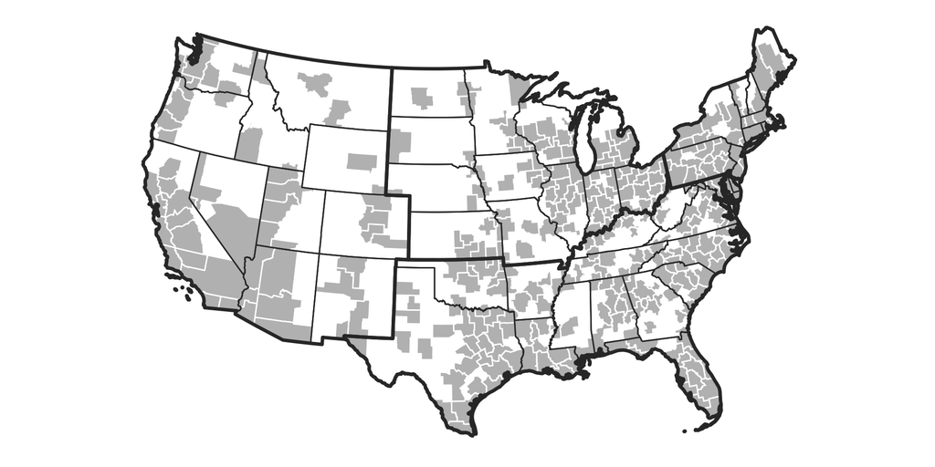

## Model Specification

$$\Delta G_{it} = \gamma_{t} + \beta_{1} \Delta IPW_{uit} + \mathbf{X}'\beta_2 + \epsilon_{it}$$

- where,
  - $\Delta G_{it}$ is the decadal change in the net number of special districts in commuting zone *i*
  - $\Delta IPW_{uit}$ is the change in import exposure, instrumented with $\Delta IPW_{oit}$
  - $\gamma_{t}$ is included in the 1991-2011 regressions, excluded in the 1991-2001 or 2001-2011 regressions
  - $X$ is a vector of control variables

## Baseline results

|  | I. 1991-2011 1991-2001 | I. 1991-2011 2001-2011 | I. 1991-2011 1991-2011 | II. 1971-1991 (pre-exposure) 1971-1981 | II. 1971-1991 (pre-exposure) 1981-1991 | II. 1971-1991 (pre-exposure) 1971-1991 |
| --- | --- | --- | --- | --- | --- | --- |
| ($\Delta$ current period imports from China to USA)/worker | -3.479* | -3.007** | -3.114*** |  |  |  |
|  | (1.497) | (0.938) | (0.828) |  |  |  |
| ($\Delta$ future period imports from China to USA)/worker |  |  |  | -0.310 | -0.280 | -0.240 |
|  |  |  |  | (1.422) | (0.533) | (0.689) |
| N | 318 | 318 | 636 | 315 | 316 | 631 |

## Baseline results

|  | (1) | (2) | (3) | (4) |
| --- | --- | --- | --- | --- |
| ($\Delta$ imports from China to USA)/ worker | -3.114*** | -3.012*** | -2.078** | -1.936** |
|  | (0.828) | (0.770) | (0.633) | (0.670) |
| Population | 0.001 | -0.001 | -0.000 | -0.002 |
|  | (0.001) | (0.002) | (0.002) | (0.002) |
| Total districts |  | 0.050 | 0.047 | 0.044 |
|  |  | (0.051) | (0.052) | (0.049) |
| Income, per capita |  |  |  | 0.898* |
|  |  |  |  | (0.422) |
| Census region dummies | No | No | Yes | Yes |
| ($\Delta$ imports from China to OTH)/ worker | 0.074*** | 0.074*** | 0.072*** | 0.072*** |
|  | (0.005) | (0.005) | (0.006) | (0.006) |

## Newly created districts

|  | 1991-2011, stacked first differences (1) | 1991-2011, stacked first differences (2) | 1991-2011, stacked first differences (3) | 1991-2011, stacked first differences (4) |
| --- | --- | --- | --- | --- |
| ($\Delta$ imports from China to USA)/ worker | -2.611** | -2.073** | -1.468* | -1.340* |
|  | (0.998) | (0.724) | (0.615) | (0.646) |
| Population | 0.011*** | 0.001 | 0.001 | -0.000 |
|  | (0.002) | (0.002) | (0.002) | (0.002) |
| Total districts |  | 0.266*** | 0.268*** | 0.265*** |
|  |  | (0.060) | (0.062) | (0.059) |
| Income, per capita |  |  |  | 0.804 |
|  |  |  |  | (0.435) |
| Census region dummies | No | No | Yes | Yes |
| N | 636 | 636 | 636 | 636 |

## Dissolved districts

|  | 1991-2011, stacked first differences (1) | 1991-2011, stacked first differences (2) | 1991-2011, stacked first differences (3) | 1991-2011, stacked first differences (4) |
| --- | --- | --- | --- | --- |
| ($\Delta$ imports from China to USA)/ worker | 0.736 | 1.097* | 0.876 | 0.874 |
|  | (0.625) | (0.514) | (0.502) | (0.510) |
| Population | 0.009*** | 0.002 | 0.002 | 0.002 |
|  | (0.002) | (0.002) | (0.002) | (0.002) |
| Total districts |  | 0.179*** | 0.180*** | 0.180*** |
|  |  | (0.023) | (0.025) | (0.025) |
| Income, per capita |  |  |  | -0.008 |
|  |  |  |  | (0.218) |
| Census region dummies | No | No | Yes | Yes |
| N | 636 | 636 | 636 | 636 |

## Conclusions

- Depending on the specification, a $1,000 increase in import exposure per worker leads to between 1.9 and 3.1 district reduction among urban and urban adjacent commuting zones
  - The results appear driven by a reduction in newly created districts
- As manufacturers
  - decline in local influence or
  - their relative demand for services declines
- The necessity for new districts also declines and fewer districts are created

## Conclusions

- As Schneider and Teske (1992) note, identifying political entrepreneurs (of which, boundary change entrepreneurs are a subset) is exceedingly difficult outside of rigorous case studies
- While not perfect, looking for shocks to groups that may contain such entrepreneurs can attempt to approximate their impact
- This study demonstrates that approach is viable

# Thank you

## References

Autor, David H, David Dorn, and Gordon H Hanson. 2013. “The China Syndrome: Local Labor Market Effects of Import Competition in the United States.” *American Economic Review* 103 (6): 2121–68. https://doi.org/10.1257/aer.103.6.2121.

Burns, Nancy. 1994. *The Formation of American Local Governments: Private Values in Public Institutions*. New York: Oxford University Press.

Carr, Jered B. 2004. “Whose Game Do We Play? Local Government Boundary Change and Metropolitan Governance.” In, edited by Richard C. Feiock, 212239. Washington, D.C.: Georgetown University Press.

Feiock, Richard C., and Jered B. Carr. 2001. “Incentives, Entrepreneurs, and Boundary Change: A Collective Action Framework.” *Urban Affairs Review* 36 (3): 382–405. https://doi.org/10.1177/10780870122184902.

Foster, Kathryn A. 1997. *The Political Economy of Special-Purpose Government*. Washington, DC: Georgetown University Press.

Goodman, Christopher B., and Suzanne M. Leland. 2019. “Do Cities and Counties Attempt to Circumvent Changes in Their Autonomy by Creating Special Districts?” *The American Review of Public Administration* 49 (2): 3–27. https://doi.org/10.1177/0275074018804665.

———. 2025. “What Lies Beneath These Creatures of the State: Understanding the Death of Specialised Governments in the u.s.” *Local Government Studies*. https://doi.org/10.1080/03003930.2024.2360559.

Schneider, Mark, and Paul Teske. 1992. “Toward a Theory of the Political Entrepreneur: Evidence from Local Government.” *The American Political Science Review* 86 (3): 737–47. https://doi.org/10.2307/1964135.